# Explore and compare structured and unstructured data for the Western Cape at pentad resolution

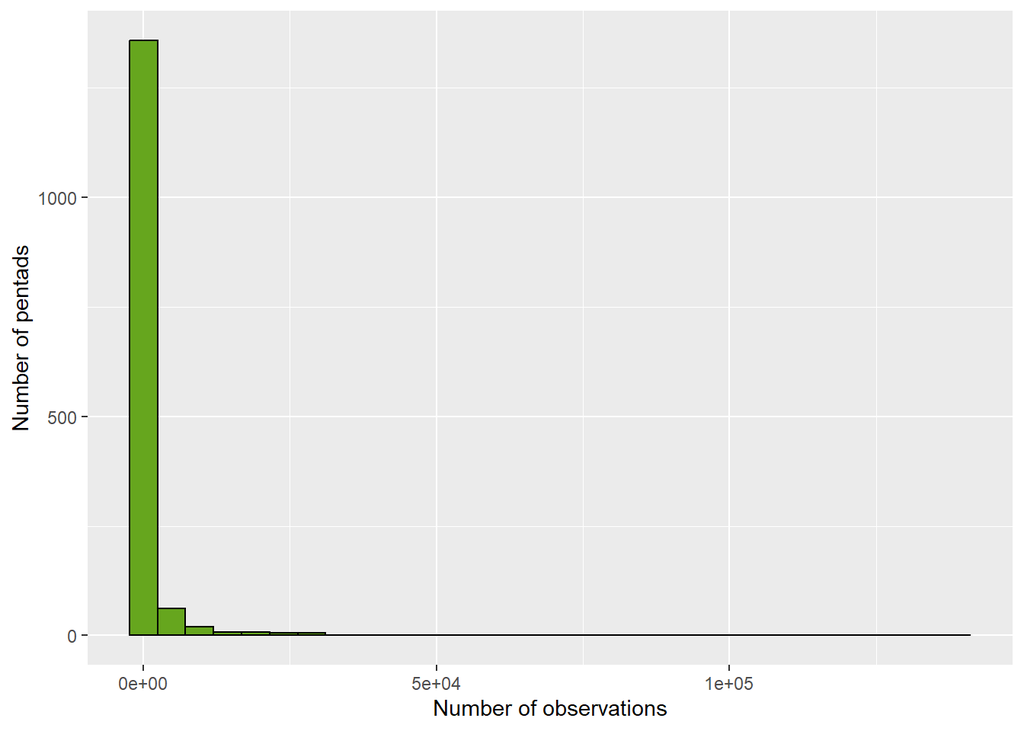

```r
# Number of observations per pentad
UnstrucWC %>%
  group_by(pentad) %>%
  summarise(n_obs = sum(n)) %>%
  ggplot(aes(x = n_obs)) +
  geom_histogram(fill = "#66A61E", color = "black") +
  labs(x = "Number of observations",
       y = "Number of pentads")
```

Number of observations vary across pentads. A few pentads have > 32 000 observations, but most < 100 observations

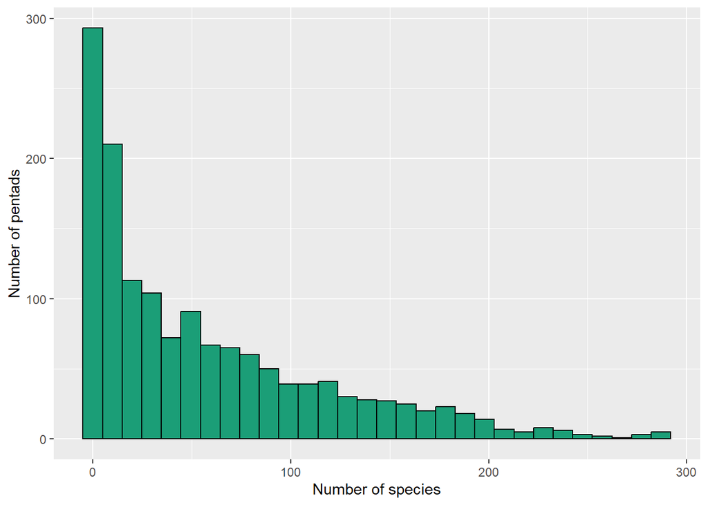

```r
# Number of species per pentad
UnstrucWC %>%
  group_by(pentad) %>%
  summarise(nSpp = n_distinct(species)) %>%
  ggplot(aes(x = nSpp)) +
  geom_histogram(fill = "#1B9E77", color = "black") +
  labs(x = "Number of species",
       y = "Number of pentads")
```

Number of species varies across pentads. Most have < 50 species, but ~40 have > 200 species.

# Comparing structured and unstructured data (2008-2024)

Note the SABAP2 dataset used below contains only pentads for the Western Cape (1842 pentads, according to the sampling framework), data from 2008 to 2023, and the geometry and NA species have been removed. Data for 2023 are incomplete. There are also only records in 1681 pentads.

The unstructured data used below contains only pentads for the Western Cape (1842 pentads, according to the SABAP2 sampling framework), data from 2008 to 2024, and the geometry has been removed. Note data for 2024 are incomplete. There are also only records in 1469 pentads.

The total period 2008-2024 is used for comparison

```r
# species recorded in sabap2
studied_spec <- unique(SABAP2WC$species) %>%
  na.omit()
```

## Species overlap between two datasets

```r
# calculate number and percentage of species in sabap2 that are in unstructured data
SppOverlapInd<-which(UnstrucWC$species %in% studied_spec)
SppOverlap<-unique(UnstrucWC$species[SppOverlapInd]) # overlapping species
NoSppOverlap<-length(SppOverlap)
PercSppOverlap<-NoSppOverlap/length(studied_spec)*100
NoSppOverlap # number of species in unstructured data that are in sabap2 data
```

```
## [1] 493
```

```r
PercSppOverlap # percentage of species in sabap2 data that are in unstructured data
```

```
## [1] 98.20717
```

493 species in both datasets. 98% of species in SABAP2 dataset are in the unstructured data

```r
# how common (based on sabap2) are the overlapping species, and not-overlapping species
ind<-which(SABAP2WC$species %in% SppOverlap)
SppOverlapDeats<-unique(SABAP2WC[ind,c('species', 'category')])
commonOverlap<-SppOverlapDeats %>%
group_by(category) %>%
  summarise(overlap = n())

SppNotOverlapDeats<-unique(SABAP2WC[-ind,c('species', 'category')])
commonNotOverlap<-SppNotOverlapDeats %>%
group_by(category) %>%
  summarise(notOverlap = n())

commonOverlap %>%
left_join(commonNotOverlap, by = join_by(category)) %>%
  rowwise() %>%
  mutate(total = sum(overlap,notOverlap)) %>%
 mutate(perc = overlap/total*100)
```

```
## # A tibble: 5 × 5
## # Rowwise:
##   category         overlap notOverlap total  perc
##   <fct>              <int>      <int> <int> <dbl>
## 1 Very rare             79          7    86  91.9
## 2 Rare                  80          1    81  98.8
## 3 Common                94         NA    NA  NA
## 4 Very common          161          1   162  99.4
## 5 Extremely common      79         NA    NA  NA
```

Of the 502 species in the SABAP2 data, 493 are in the unstructured data (98%). Of the 493, 79 are very rare, 80 are rare, 94 are common, 161 very common, and 79 are extremely common. Of the 9 species in SABAP2 that are missing from the unstructured data 7 are very rare, 1 rare, none are common, 1 is very common, and none is extremely common. Therefore, species seemed more likely to not be recorded if very rare/rare.

```r
# calculate number and percentage of species in unstructured data that are in SABAP2
SppOverlapInd2<-which(studied_spec %in% UnstrucWC$species)
SppOverlap2<-unique(studied_spec[SppOverlapInd2]) # overlapping species
NoSppOverlap2<-length(SppOverlap2)
PercSppOverlap2<-NoSppOverlap2/length(unique(UnstrucWC$species))*100
PercSppOverlap2 # percentage of species in unstructured data that are in SABAP2
```

```
## [1] 77.51572
```

78% of the species in the unstructured data are in SABAP2

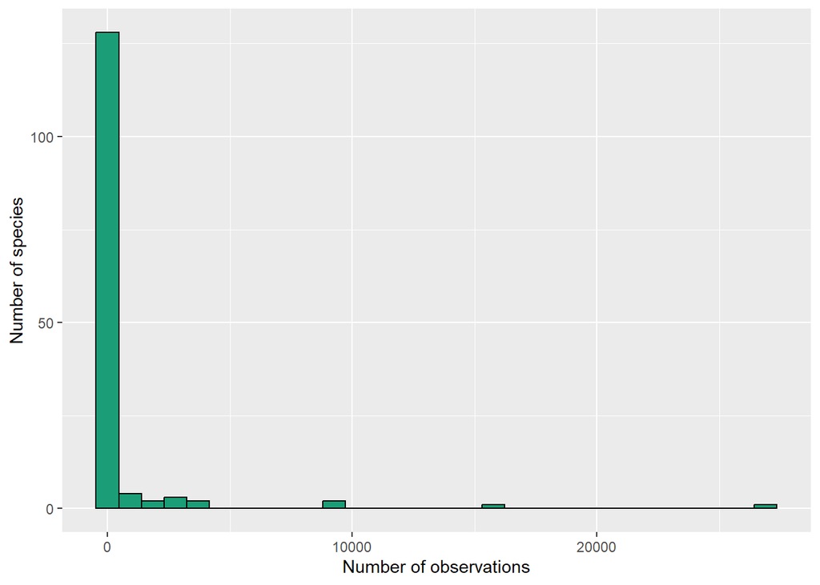

```r
# what are these not-overlapping species
ind2<-which(UnstrucWC$species %in% SppOverlap2)
SppNotOverlap2<-unique(UnstrucWC[-ind2,])
SppNotOverlapDeats2<-unique(UnstrucWC[-ind2,c('species')])

SppNotOverlap2 %>%
group_by(species) %>%
  summarise(nObs = sum(n)) %>%
   ggplot(aes(x = nObs)) +
  geom_histogram(fill = "#1B9E77", color = "black") +
  labs(x = "Number of observations",
       y = "Number of species")
```

There are 143 species in the unstructured data that are not in the SABAP2 data. For 126 of these species there are <= 65 records. For the 17 species for which there are > 65 records, the details are below. However, of these 17, a number seem to be missidentifications or there are multiple accepted species names in GBIF. For a number, however, there seems to be an issue with the data flowing into GBIF, as these species should be included in the SABAP2 data. Note the SABAP2 data does go through quality control. All comparisons below are based on the species in SABAP2.

- *Chloephaga hybrida* (kelp goose) (178 records): likely missidentifications, as the species does not occur in South Africa.
- *Alectoris chukar* (chukar) (218 records): alien species that is found on Robben Island (inshore island off Western Cape coast). Records elsewhere could be errors. Robben island does fall under Western Cape, so SABAP2 data should include *Alectoris chukar*. This pentad is not included when SABAP2 data are downloaded for Western Cape from GBIF.
- *Anthus nicholsoni* (Nicholson’s Pipit) (596 records): Also an accepted species name in GBIF is *Anthus similis* (Jerdon, 1840), for which the common names are Long-billed pipit (in English) and Nicholsonkoester (in Afrikaans). *Anthus similis* is in the SABAP2 data.
- *Tychaedon coryphoeus* (Karoo scrub-robin) (1106 records): Two accepted species names in GBIF (*Tychaedon coryphoeus* (Lesson, 1831) and *Erythropygia coryphoeus* (Vieillot, 1817)). Appears in SABAP2 under *Erythropygia coryphoeus*.
- *Prinia hypoxantha* (Drakensberg Prinia) (1109 records). Likely missidentifications. Species does not occur in Western Cape.
- *Sylvia layardi* (Layard’s Warbler) (1252 records). On SABAP2 website appears under the synonym ‘*Curruca layardi* (Hartlaub, 1862)’, but the species is not under this name in SABAP2 data downloaded from GBIF.
- *Acrocephalus scirpaceus* (common reed warbler) (1525 records). This species is a rare summer visitor with few records in southern Africa, not really from Western Cape. Possible missidentifications?
- *Curruca subcoerulea* (Chestnut-vented Warbler) (2119 records): Many records in Western Cape for this species on SABAP2 website, but does not appear in data downloaded from GBIF.
- *Macronyx capensis* (Cape Longclaw) (2966 records): Area is part of range. Many records in Western Cape for this species on SABAP2 website, but does not appear in data downloaded from GBIF.
- *Upupa epops* (Hoopoe) (3050 records): two accepted species names in GBIF (*Upupa epops* Linnaeus, 1758 and *Upupa africana* Bechstein, 1811). The species appears under the name *Upupa africana* in SABAP2 data.
- *Dessonornis caffer* (Cape Robin-Chat) (3159 records): Cape Robin-Chat appears to have two accepted species names in GBIF (*Cossypha caffra* (Linnaeus, 1771) and *Dessonornis caffer* (Linnaeus, 1771)). It is under *Cossypha caffra* in SABAP2.
- *Psalidoprocne pristoptera* (black saw-wing) (3685 records): area is within its range. Many records in Western Cape for this species on SABAP2 website, but does not appear in data downloaded from GBIF.
- *Buteo buteo* (buzzard) (4143 records). Many records in Western Cape for this species on SABAP2 website, but does not appear in data downloaded from GBIF.
- *Euplectes capensis* (yellow bishop) (9486 records). Many records in Western Cape for this species on SABAP2 website, but does not appear in data downloaded from GBIF.
- *Phoenicopterus roseus* (greater flamingo) (9582 records): Many records in Western Cape for this species on SABAP2 website, but does not appear in data downloaded from GBIF.
- *Phalacrocorax carbo* (common cormorant) (15506 records): possible misidentification. Maybe being confused with *Phalacrocorax capensis* (cape cormorant), which does occur in the area and is in the SABAP2 data.
- *Zosterops virens* (Cape white-eye) (26880 records): two accepted names in GBIF (*Zosterops virens* Sundevall, 1850 and *Zosterops capensis* Sundevall, 1850). Many records in Western Cape for this species on SABAP2 website, but does not appear in data downloaded from GBIF.

## Range overlap

```r
# function to compare ranges from the two datasets
range_comp <- function(sel_species, period = 2008:2024,
                       dataset1 = SABAP2WC,
                       dataset2 = UnstrucWC) {

  # We filter both datasets for the species and period of interest
  # and group them by pentad
  set_sabap2 <- dataset1 %>%
    st_drop_geometry() %>%
    filter(.data$species %in% sel_species,
           .data$year %in% period) %>%
    group_by(.data$pentad) %>%
    summarise(n = n()) # no observations rather than no individuals

  set_cube <- dataset2 %>%
    st_drop_geometry() %>%
    filter(.data$species %in% sel_species,
           .data$year %in% period) %>%
    group_by(.data$pentad) %>%
    summarise(n = sum(.data$n))

  total_sabap2 <- length(set_sabap2$pentad)
  perc_sabap2 <- (total_sabap2 / 1842) * 100 # have taken the value to be total number of grid cells in area of interest

  total_cube <- length(set_cube$pentad)
  perc_cube <- (total_cube / 1842) * 100 # have taken the value to be total number of grid cells in area of interest

  overlap_all_sabap2_cube <- length(
    which(set_cube$pentad %in% unique(dataset1$pentad))
    )
  perc_overlap_all <- (overlap_all_sabap2_cube / 1842) * 100 # have taken the value to be total number of grid cells in the sabap2 data

  total_overlap <- length(which(set_cube$pentad %in% set_sabap2$pentad))
  perc <- (total_overlap / total_sabap2) * 100

  list(total_sabap2, perc_sabap2,
       total_cube, perc_cube,
       overlap_all_sabap2_cube, perc_overlap_all,
       total_overlap, perc)
}
```

```r
# run function
comp_range_data <- as.data.frame(studied_spec)
comp_range_data$sabap2_squares <- NA
comp_range_data$perc_sabap2_total_sabap2 <- NA
comp_range_data$cube_squares <- NA
comp_range_data$perc_cube_total_cube <- NA
comp_range_data$overlap_birdcube_total_sabap2 <- NA
comp_range_data$perc_birdcube_total_sabap2 <- NA
comp_range_data$overlap_birdcube_spec_sabap2 <- NA
comp_range_data$percentage_birdcube_spec_sabap2 <- NA

for (i in studied_spec){
  test <- range_comp(i, period = 2008:2024)

  comp_range_data[comp_range_data$studied_spec == i, 2] <- test[1]
  comp_range_data[comp_range_data$studied_spec == i, 3] <- test[2]
  comp_range_data[comp_range_data$studied_spec == i, 4] <- test[3]
  comp_range_data[comp_range_data$studied_spec == i, 5] <- test[4]
  comp_range_data[comp_range_data$studied_spec == i, 6] <- test[5]
  comp_range_data[comp_range_data$studied_spec == i, 7] <- test[6]
  comp_range_data[comp_range_data$studied_spec == i, 8] <- test[7]
  comp_range_data[comp_range_data$studied_spec == i, 9] <- test[8]
}
```

```r
# Table of output
comp_range_data %>%
  inner_join(SABAP2WC %>% distinct(species, category),
            by = join_by(studied_spec == species)) %>%
  DT::datatable() %>%
  DT::formatRound(columns = c("perc_sabap2_total_sabap2",
                              "perc_cube_total_cube",
                              "perc_birdcube_total_sabap2",
                              "percentage_birdcube_spec_sabap2"), digits = 2)
```

|  | studied_spec | sabap2_squares | perc_sabap2_total_sabap2 | cube_squares | perc_cube_total_cube | overlap_birdcube_total_sabap2 | perc_birdcube_total_sabap2 | overlap_birdcube_spec_sabap2 | percentage_birdcube_spec_sabap2 | category |
| --- | --- | --- | --- | --- | --- | --- | --- | --- | --- | --- |
| 1 | Emarginata schlegelii | 867 | 47.06840390879479 | 271 | 14.71226927252986 | 258 | 14.00651465798046 | 213 | 24.5674740484429 | Very common |
| 2 | Telophorus zeylonus | 1541 | 83.65906623235614 | 697 | 37.83930510314875 | 630 | 34.20195439739413 | 622 | 40.36340038935757 | Extremely common |
| 3 | Passer melanurus | 1583 | 85.93919652551575 | 782 | 42.45385450597177 | 721 | 39.14223669923996 | 710 | 44.85154769425142 | Extremely common |
| 4 | Ploceus capensis | 1191 | 64.65798045602605 | 738 | 40.06514657980456 | 671 | 36.42779587404995 | 651 | 54.65994962216625 | Extremely common |
| 5 | Ptyonoprogne fuligula | 1530 | 83.06188925081433 | 594 | 32.24755700325733 | 541 | 29.37024972855592 | 519 | 33.92156862745098 | Extremely common |
| 6 | Nectarinia famosa | 1348 | 73.1813246471227 | 659 | 35.77633007600434 | 600 | 32.57328990228013 | 570 | 42.28486646884273 | Extremely common |
| 7 | Emberiza capensis | 1392 | 75.57003257328991 | 583 | 31.65038002171552 | 524 | 28.44733984799132 | 489 | 35.12931034482759 | Extremely common |
| 8 | Crithagra albogularis | 1356 | 73.61563517915309 | 454 | 24.6471226927253 | 421 | 22.85559174809989 | 391 | 28.83480825958702 | Extremely common |
| 9 | Prinia maculosa | 1595 | 86.59066232356135 | 773 | 41.96525515743757 | 701 | 38.05646036916395 | 695 | 43.57366771159874 | Extremely common |
| 10 | Melierax canorus | 943 | 51.19435396308361 | 450 | 24.4299674267101 | 428 | 23.23561346362649 | 325 | 34.4644750795334 | Very common |

[output cut: 492 more lines]

This table shows the number of sabap2 grid cells (squares) where a species was observed, the percentage of total sabap2 grid cells, the number of cube grid cells were the species was observed, the percentage of all cube grid cells, the number of sabap2 grid cells where the species was observed based on the birdcube data, the percentage compared to all sabap2 grid cells, the number of grid cells occupied by the species in both the sabap2 and birdcube data and the percentage of this compared to the number of grid cells occupied by this species in the sabap2 data.

```r
# summary of output
summary(comp_range_data)
```

```
##  studied_spec       sabap2_squares   perc_sabap2_total_sabap2  cube_squares
##  Length:502         Min.   :   1.0   Min.   : 0.05429         Min.   :  0.00
##  Class :character   1st Qu.:   8.0   1st Qu.: 0.43431         1st Qu.: 10.25
##  Mode  :character   Median :  84.0   Median : 4.56026         Median : 69.50
##                     Mean   : 306.6   Mean   :16.64655         Mean   :158.83
##                     3rd Qu.: 515.8   3rd Qu.:27.99946         3rd Qu.:229.75
##                     Max.   :1595.0   Max.   :86.59066         Max.   :838.00
##  perc_cube_total_cube overlap_birdcube_total_sabap2 perc_birdcube_total_sabap2
##  Min.   : 0.0000      Min.   :  0.0                 Min.   : 0.0000
##  1st Qu.: 0.5565      1st Qu.:  8.0                 1st Qu.: 0.4343
##  Median : 3.7731      Median : 56.0                 Median : 3.0402
##  Mean   : 8.6229      Mean   :141.3                 Mean   : 7.6720
##  3rd Qu.:12.4729      3rd Qu.:205.2                 3rd Qu.:11.1428
##  Max.   :45.4940      Max.   :773.0                 Max.   :41.9653
##  overlap_birdcube_spec_sabap2 percentage_birdcube_spec_sabap2
##  Min.   :  0.0                Min.   :  0.00
##  1st Qu.:  3.0                1st Qu.: 26.12
##  Median : 32.0                Median : 40.83
##  Mean   :115.6                Mean   : 43.38
##  3rd Qu.:147.0                3rd Qu.: 53.29
##  Max.   :769.0                Max.   :100.00
```

Overall we see an overlap of 43%

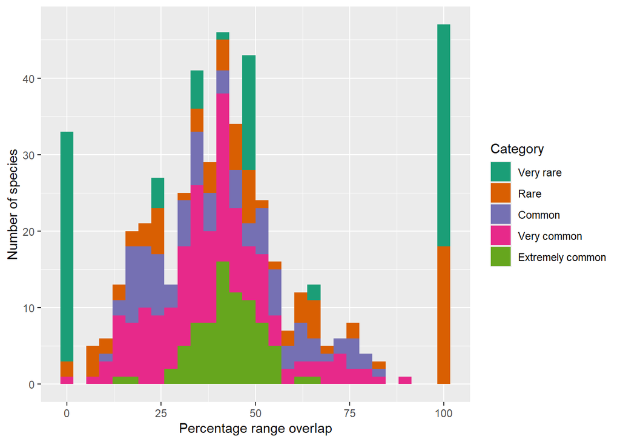

```r
# plot percentage range overlap
comp_range_data %>%
  inner_join(SABAP2WC %>% distinct(species, category),
            by = join_by(studied_spec == species)) %>%
  ggplot(aes(x = percentage_birdcube_spec_sabap2,fill = category)) +
  geom_histogram() +
  fillScale +
  labs(x = "Percentage range overlap",
       y = "Number of species")
```

Many species have very low percentage range overlap, most have < 50% overlap (39 have < 10% overlap). The outliers with high percentage overlap are a rare/very rare species.

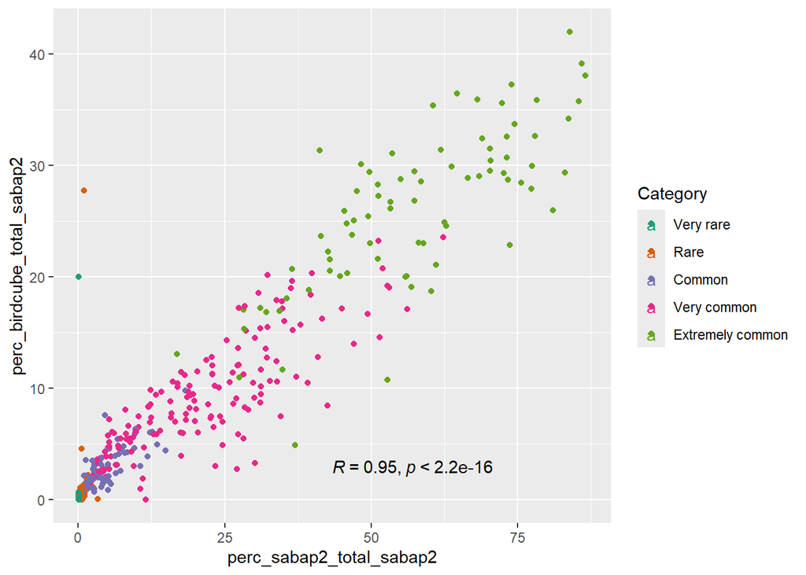

```r
# Plot percentage of SABAP2 grid cells in which species recorded in SABAP2 vs percentage overlapping cells in cube
comp_range_data %>%
  inner_join(SABAP2WC %>% distinct(species, category),
            by = join_by(studied_spec == species)) %>%
  ggplot(aes(x = perc_sabap2_total_sabap2, y = perc_birdcube_total_sabap2, color = category)) +
  geom_point() +
  colScale +
  ggpubr::stat_cor(mapping = aes(color = NULL),
           label.x.npc = "centre",
           label.y.npc = "bottom",
           method = "pearson")
```

If we look at the graph it appears that of the sabap2 grid cells the percentage of grid cells in which a species is observed in sabap2 is positively correlated to the percentage grid cells in which there is overlap between the sabap2 records and cube records.

### All species in SABAP2

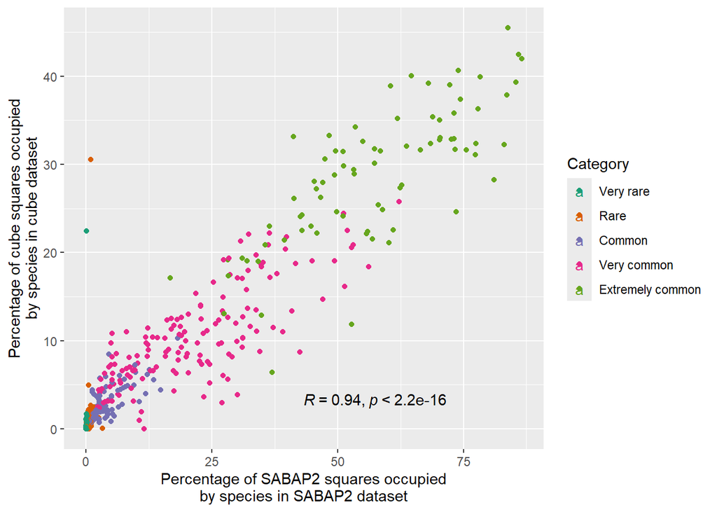

```r
# Plot percentage of SABAP2 grid cells in which species recorded in SABAP2 vs percentage of cells in which recorded in unstructured data
comp_range_data %>%
  inner_join(SABAP2WC %>% distinct(species, category),
            by = join_by(studied_spec == species)) %>%
  ggplot(aes(x = perc_sabap2_total_sabap2, y = perc_cube_total_cube, color = category)) +
  geom_point() +
  colScale +
  ggpubr::stat_cor(mapping = aes(color = NULL),
           label.x.npc = "centre",
           label.y.npc = "bottom",
           method = "pearson")+
  labs(x = "Percentage of SABAP2 squares occupied\nby species in SABAP2 dataset",
       y = "Percentage of cube squares occupied\nby species in cube dataset")
```

If we look at the graph it appears that of the sabap2 grid cells the percentage of grid cells in which a species is observed in sabap2 is positively correlated to the percentage grid cells in which a species is recorded in the unstructured data. But note these grid cells might not overlap

### Only common, very common, and extremely common species in SABAP2

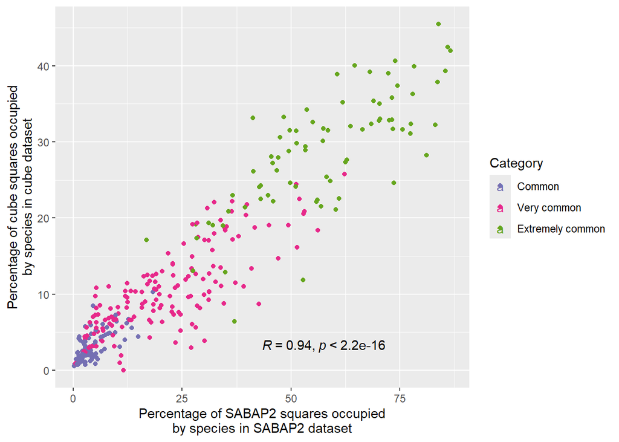

```r
# same plot as previous, but not including rare and very rare species
comp_range_data %>%
  inner_join(SABAP2WC %>% distinct(species, category),
            by = join_by(studied_spec == species)) %>%
  filter(category %in% c("Common", "Very common", "Extremely common")) %>%
  ggplot(aes(x = perc_sabap2_total_sabap2, y = perc_cube_total_cube, color = category)) +
  geom_point() +
  colScale +
  ggpubr::stat_cor(mapping = aes(color = NULL),
           label.x.npc = "centre",
           label.y.npc = "bottom",
           method = "pearson")+
  labs(x = "Percentage of SABAP2 squares occupied\nby species in SABAP2 dataset",
       y = "Percentage of cube squares occupied\nby species in cube dataset")
```

For common and very common species (rare excluded) - If we look at the graph it appears that of the SABAP2 grid cells the percentage of grid cells in which a species is observed in SABAP2 is positively correlated to the percentage grid cells in which a species is recorded in the unstructured data. But these grid cells might not overlap.

## Range overlap over time

```r
# Calculate range overlap metrics for two-year periods
comp_range_data2 <- data.frame(studied_spec = rep(studied_spec, 6),
                               sabap2_squares = NA,
                               perc_sabap2_total_sabap2 = NA,
                               cube_squares = NA,
                               perc_cube_total_cube = NA,
                               percentage_birdcube_spec_sabap2 = NA, #added
                               cyclus = NA)

start_year <- 2008
end_year <- 2024

cycle_starts <- seq(from = start_year, to = end_year, by = 3)
c = 1
j = 1

for (cycle_start in cycle_starts) {
  for (i in studied_spec) {
    comp_range_data2$cyclus[j] <- c
    comp_range_data2$studied_spec[j] = i

    test <- range_comp(i, period = cycle_start:(cycle_start + 3))

    comp_range_data2$sabap2_squares[j] <- test[[1]]
    comp_range_data2$perc_sabap2_total_sabap2[j] <- test[[2]]
    comp_range_data2$cube_squares[j] <- test[[3]]
    comp_range_data2$perc_cube_total_cube[j] <- test[[4]]
    comp_range_data2$percentage_birdcube_spec_sabap2[j] <- test[[8]] # added

    j = j + 1
  }
  c = c + 1
}
```

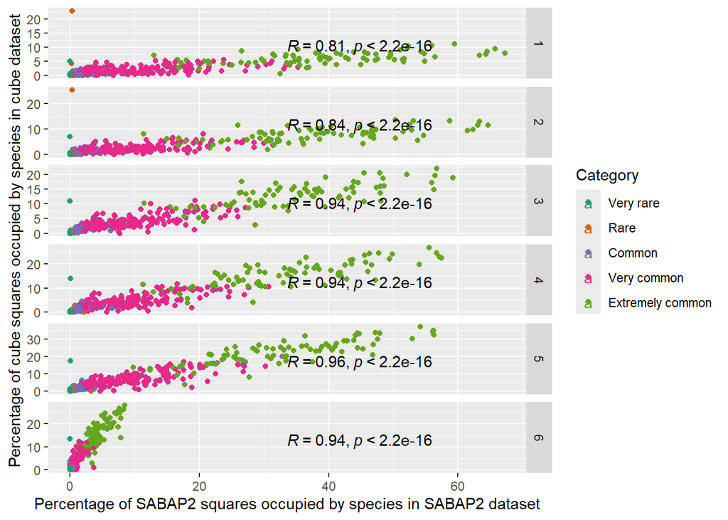

```r
# Plot percentage cells in which species were recorded in sabap2 vs in unstructured data for each three-year period
comp_range_data2 %>%
  inner_join(SABAP2WC %>% distinct(species, category),
            by = join_by(studied_spec == species)) %>%
  ggplot(aes(x = perc_sabap2_total_sabap2, y = perc_cube_total_cube, color = category)) +
  geom_point() +
  colScale +
  ggpubr::stat_cor(mapping = aes(color = NULL),
           label.x.npc = "centre",
           label.y.npc = "bottom",
           method = "pearson") +
  facet_grid("cyclus",
             scales = "free_y")+ labs(x = "Percentage of SABAP2 squares occupied by species in SABAP2 dataset",
       y = "Percentage of cube squares occupied by species in cube dataset")
```

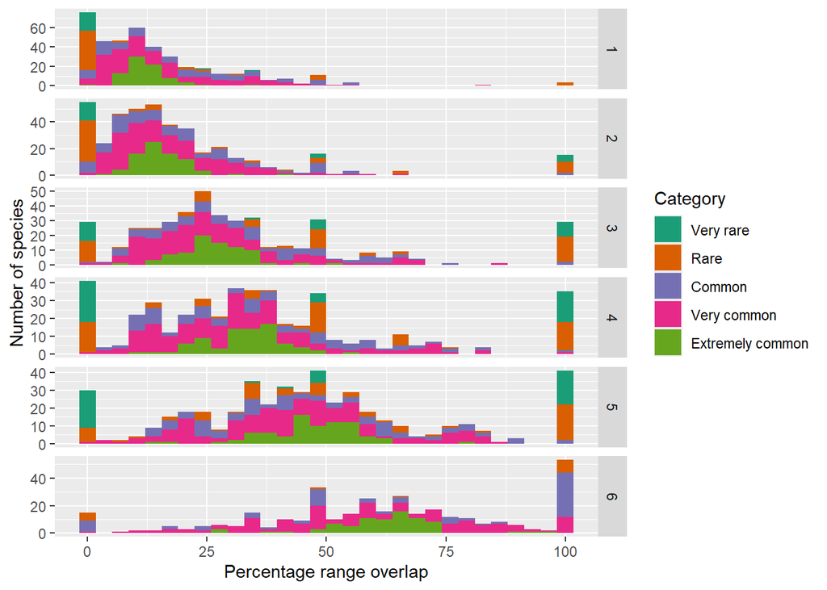

```r
# plot percentage range overlap for each period
comp_range_data2 %>%
  inner_join(SABAP2WC %>% distinct(species, category),
            by = join_by(studied_spec == species)) %>%
  ggplot(aes(x = percentage_birdcube_spec_sabap2,fill = category)) +
  geom_histogram() +
  fillScale +
  labs(x = "Percentage range overlap",
       y = "Number of species") + facet_grid("cyclus", scales = "free_y")
```

# Comparing structured and unstructured data (2008-2022)

Below is the same analysis as above but the period of data covered are for 2008-2022, when both SABAP2 and unstructured data are available.

Note, while the specific values vary the results and conclusions are similar to that for the period 2008-2024

```r
# remove data from 2023 and 2024
SABAP2WCSub<-SABAP2WC %>%
  filter(cyclus != "6")

UnstrucWCSub<-UnstrucWC %>%
  filter(cyclus != "6")
```

```r
# species recorded in sabap2
studied_spec <- unique(SABAP2WCSub$species) %>%
  na.omit()
```

## Species overlap between two datasets

```r
# calculate number and percentage of species in sabap2 that are in unstructured data
SppOverlapSubInd<-which(UnstrucWCSub$species %in% studied_spec)
SppOverlapSub<-unique(UnstrucWCSub$species[SppOverlapSubInd]) # overlapping species
NoSppOverlapSub<-length(SppOverlapSub)
PercSppOverlapSub<-NoSppOverlapSub/length(studied_spec)*100
NoSppOverlapSub # number of species in unstructured data that are in sabap2 data
```

```
## [1] 490
```

```r
PercSppOverlapSub # percentage of species in sabap2 data that are in unstructured data
```

```
## [1] 97.60956
```

490 species appear in both the structured and unstructured datasets, this represents 98% of the species recorded in SABAP2.

```r
# how common (based on sabap2) are the overlapping species, and not-overlapping species
ind<-which(SABAP2WCSub$species %in% SppOverlapSub)
SppOverlapDeatsSub<-unique(SABAP2WCSub[ind,c('species', 'category')])
commonOverlap<-SppOverlapDeatsSub %>%
group_by(category) %>%
  summarise(overlap = n())

SppNotOverlapDeatsSub<-unique(SABAP2WCSub[-ind,c('species', 'category')])
commonNotOverlap<-SppNotOverlapDeatsSub %>%
group_by(category) %>%
  summarise(notOverlap = n())

commonOverlap %>%
  left_join(commonNotOverlap, by = join_by(category)) %>%
  rowwise() %>%
  mutate(total = sum(overlap,notOverlap)) %>%
  mutate(perc = overlap/total*100)
```

```
## # A tibble: 5 × 5
## # Rowwise:
##   category         overlap notOverlap total  perc
##   <fct>              <int>      <int> <int> <dbl>
## 1 Very rare             76         10    86  88.4
## 2 Rare                  80          1    81  98.8
## 3 Common                94         NA    NA  NA
## 4 Very common          161          1   162  99.4
## 5 Extremely common      79         NA    NA  NA
```

```r
# calculate number and percentage of species in unstructured data that are in SABAP2
SppOverlapInd2<-which(studied_spec %in% UnstrucWCSub$species)
SppOverlap2<-unique(studied_spec[SppOverlapInd2]) # overlapping species
NoSppOverlap2<-length(SppOverlap2)
PercSppOverlap2<-NoSppOverlap2/length(unique(UnstrucWCSub$species))*100
PercSppOverlap2 # percentage of species in unstructured data that are in SABAP2
```

```
## [1] 79.28803
```

79% of the species in the unstructured data are in SABAP2

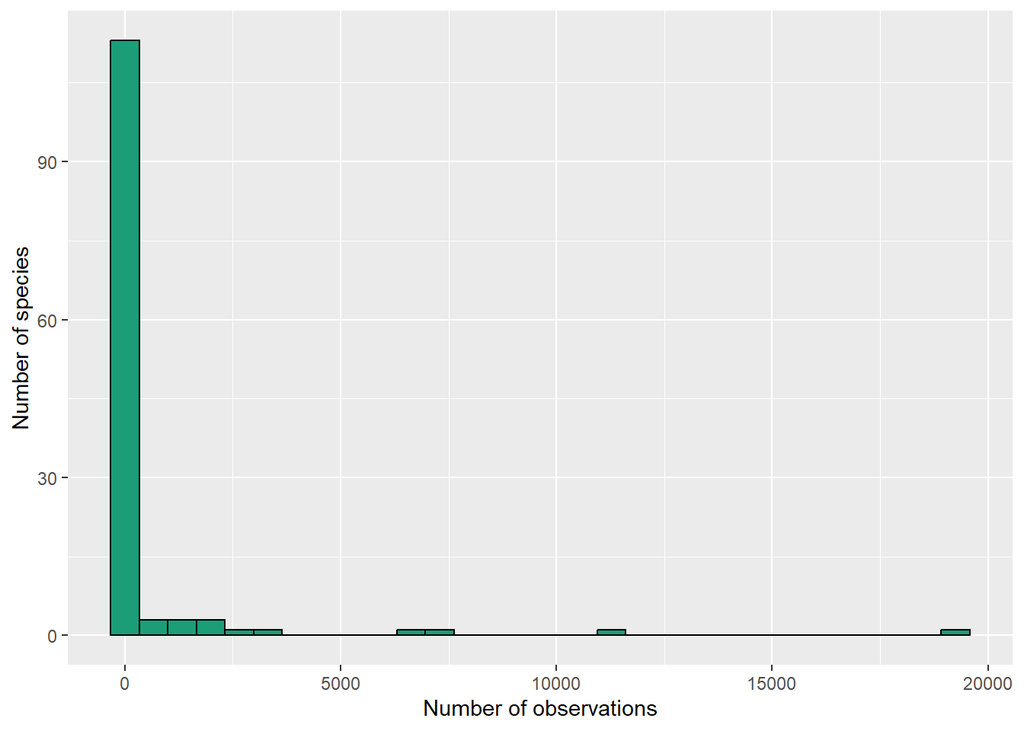

```r
# what are these not-overlapping species
ind2<-which(UnstrucWCSub$species %in% SppOverlap2)
SppNotOverlap2<-unique(UnstrucWCSub[-ind2,])
SppNotOverlapDeats2<-unique(UnstrucWCSub[-ind2,c('species')])

SppNotOverlap2 %>%
group_by(species) %>%
  summarise(nObs = sum(n)) %>%
   ggplot(aes(x = nObs)) +
  geom_histogram(fill = "#1B9E77", color = "black") +
  labs(x = "Number of observations",
       y = "Number of species")
```

There are 128 species in the unstructured data that are not in the SABAP2 data. For 111 there are < 65 records. The 17 species with > 65 records are the same species as discussed above for the period 2008-2024. Reasons are discussed above. All comparisons below are based on the species in SABAP2.

## Range overlap

```r
# function to compare ranges
range_comp <- function(sel_species, period = 2008:2022,
                       dataset1 = SABAP2WCSub,
                       dataset2 = UnstrucWCSub) {

  # We filter both datasets for the species and period of interest
  # and group them by pentad
  set_sabap2 <- dataset1 %>%
    st_drop_geometry() %>%
    filter(.data$species %in% sel_species,
           .data$year %in% period) %>%
    group_by(.data$pentad) %>%
    summarise(n = n()) # no observations rather than no individuals

  set_cube <- dataset2 %>%
    st_drop_geometry() %>%
    filter(.data$species %in% sel_species,
           .data$year %in% period) %>%
    group_by(.data$pentad) %>%
    summarise(n = sum(.data$n))

  total_sabap2 <- length(set_sabap2$pentad)
  perc_sabap2 <- (total_sabap2 / 1842) * 100 # have taken the value to be total number of grid cells in area of interest

  total_cube <- length(set_cube$pentad)
  perc_cube <- (total_cube / 1842) * 100 # have taken the value to be total number of grid cells in area of interest

  overlap_all_sabap2_cube <- length(
    which(set_cube$pentad %in% unique(dataset1$pentad))
    )
  perc_overlap_all <- (overlap_all_sabap2_cube /1842) * 100 # have taken the value to be total number of grid cells in the sabap2 data

  total_overlap <- length(which(set_cube$pentad %in% set_sabap2$pentad))
  perc <- (total_overlap / total_sabap2) * 100

  list(total_sabap2, perc_sabap2,
       total_cube, perc_cube,
       overlap_all_sabap2_cube, perc_overlap_all,
       total_overlap, perc)
}
```

```r
# run function
comp_range_data <- as.data.frame(studied_spec)
comp_range_data$sabap2_squares <- NA
comp_range_data$perc_sabap2_total_sabap2 <- NA
comp_range_data$cube_squares <- NA
comp_range_data$perc_cube_total_cube <- NA
comp_range_data$overlap_birdcube_total_sabap2 <- NA
comp_range_data$perc_birdcube_total_sabap2 <- NA
comp_range_data$overlap_birdcube_spec_sabap2 <- NA
comp_range_data$percentage_birdcube_spec_sabap2 <- NA

for (i in studied_spec){
  test <- range_comp(i, period = 2008:2022)

  comp_range_data[comp_range_data$studied_spec == i, 2] <- test[1]
  comp_range_data[comp_range_data$studied_spec == i, 3] <- test[2]
  comp_range_data[comp_range_data$studied_spec == i, 4] <- test[3]
  comp_range_data[comp_range_data$studied_spec == i, 5] <- test[4]
  comp_range_data[comp_range_data$studied_spec == i, 6] <- test[5]
  comp_range_data[comp_range_data$studied_spec == i, 7] <- test[6]
  comp_range_data[comp_range_data$studied_spec == i, 8] <- test[7]
  comp_range_data[comp_range_data$studied_spec == i, 9] <- test[8]
}
```

```r
# table of outputs
comp_range_data %>%
  inner_join(SABAP2WCSub %>% distinct(species, category),
            by = join_by(studied_spec == species)) %>%
  DT::datatable() %>%
  DT::formatRound(columns = c("perc_sabap2_total_sabap2",
                              "perc_cube_total_cube",
                              "perc_birdcube_total_sabap2",
                              "percentage_birdcube_spec_sabap2"), digits = 2)
```

|  | studied_spec | sabap2_squares | perc_sabap2_total_sabap2 | cube_squares | perc_cube_total_cube | overlap_birdcube_total_sabap2 | perc_birdcube_total_sabap2 | overlap_birdcube_spec_sabap2 | percentage_birdcube_spec_sabap2 | category |
| --- | --- | --- | --- | --- | --- | --- | --- | --- | --- | --- |
| 1 | Emarginata schlegelii | 865 | 46.95982627578719 | 223 | 12.10640608034745 | 210 | 11.40065146579805 | 174 | 20.11560693641619 | Very common |
| 2 | Telophorus zeylonus | 1539 | 83.55048859934854 | 596 | 32.35613463626493 | 534 | 28.99022801302932 | 529 | 34.37296946068876 | Extremely common |
| 3 | Passer melanurus | 1581 | 85.83061889250814 | 691 | 37.51357220412595 | 631 | 34.25624321389794 | 623 | 39.40543959519292 | Extremely common |
| 4 | Ploceus capensis | 1190 | 64.60369163952225 | 664 | 36.04777415852335 | 602 | 32.68186753528773 | 587 | 49.32773109243698 | Extremely common |
| 5 | Ptyonoprogne fuligula | 1528 | 82.95331161780673 | 518 | 28.12160694896851 | 467 | 25.3528773072747 | 449 | 29.3848167539267 | Extremely common |
| 6 | Nectarinia famosa | 1347 | 73.1270358306189 | 582 | 31.59609120521172 | 525 | 28.50162866449512 | 502 | 37.26800296956199 | Extremely common |
| 7 | Emberiza capensis | 1391 | 75.51574375678611 | 500 | 27.14440825190011 | 442 | 23.99565689467969 | 419 | 30.12221423436376 | Extremely common |
| 8 | Crithagra albogularis | 1355 | 73.56134636264929 | 373 | 20.24972855591748 | 342 | 18.56677524429967 | 314 | 23.17343173431734 | Extremely common |
| 9 | Prinia maculosa | 1591 | 86.37350705754615 | 668 | 36.26492942453854 | 599 | 32.51900108577633 | 594 | 37.33500942803268 | Extremely common |
| 10 | Melierax canorus | 937 | 50.8686210640608 | 366 | 19.86970684039088 | 347 | 18.83821932681867 | 266 | 28.38847385272145 | Very common |

[output cut: 492 more lines]

This table shows the number of sabap2 grid cells where a species was observed, the percentage of total sabap2 grid cells, the number of cube grid cells were the species was observed, the percentage of all cube grid cells, the number of sabap2 grid cells where the species was observed based on the birdcube data, the percentage compared to all sabap2 grid cells, the number of grid cells occupied by the species in both the sabap2 and birdcube data and the percentage of this compared to the number of grid cells occupied by this species in th sabap2 data.

```r
# summary of output
summary(comp_range_data)
```

```
##  studied_spec       sabap2_squares   perc_sabap2_total_sabap2  cube_squares
##  Length:502         Min.   :   1.0   Min.   : 0.05429         Min.   :  0.0
##  Class :character   1st Qu.:   8.0   1st Qu.: 0.43431         1st Qu.:  8.0
##  Mode  :character   Median :  83.5   Median : 4.53312         Median : 61.0
##                     Mean   : 305.6   Mean   :16.59215         Mean   :136.6
##                     3rd Qu.: 514.0   3rd Qu.:27.90445         3rd Qu.:193.0
##                     Max.   :1591.0   Max.   :86.37351         Max.   :750.0
##  perc_cube_total_cube overlap_birdcube_total_sabap2 perc_birdcube_total_sabap2
##  Min.   : 0.0000      Min.   :  0.00                Min.   : 0.0000
##  1st Qu.: 0.4343      1st Qu.:  6.25                1st Qu.: 0.3393
##  Median : 3.3116      Median : 48.00                Median : 2.6059
##  Mean   : 7.4173      Mean   :120.49                Mean   : 6.5415
##  3rd Qu.:10.4777      3rd Qu.:169.75                3rd Qu.: 9.2155
##  Max.   :40.7166      Max.   :687.00                Max.   :37.2964
##  overlap_birdcube_spec_sabap2 percentage_birdcube_spec_sabap2
##  Min.   :  0.0                Min.   :  0.00
##  1st Qu.:  2.0                1st Qu.: 23.54
##  Median : 29.0                Median : 36.36
##  Mean   :100.1                Mean   : 39.78
##  3rd Qu.:129.8                3rd Qu.: 50.00
##  Max.   :684.0                Max.   :100.00
```

Overall we see a range overlap of 40% (slightly lower than for 2008-2024)

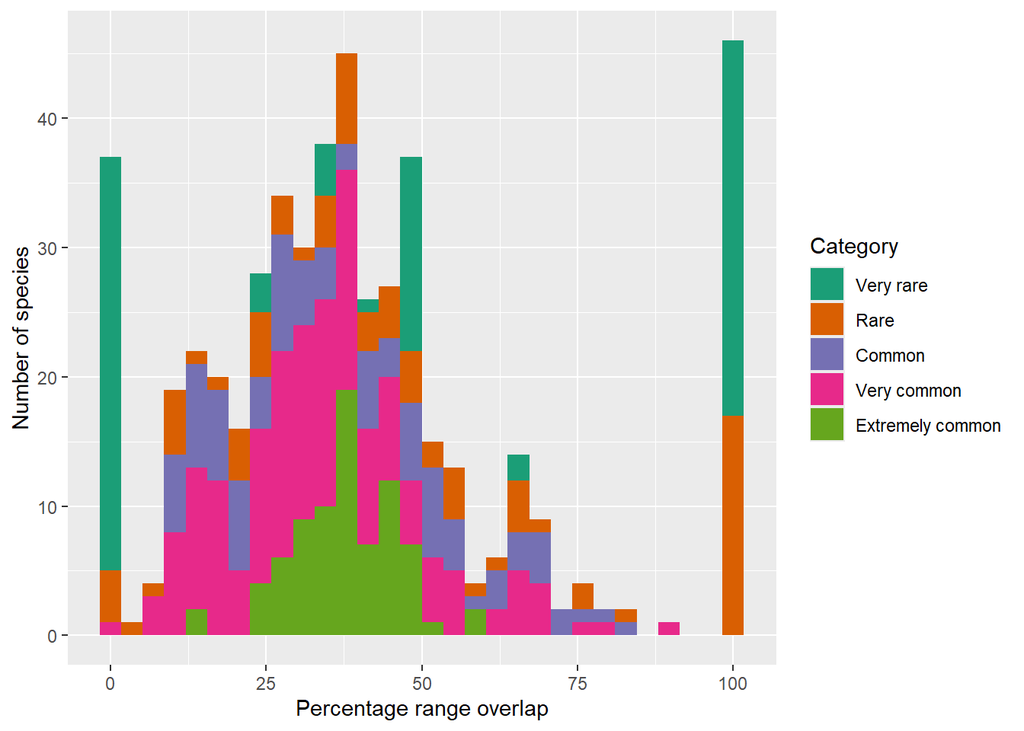

```r
# plot percentage range overlap
comp_range_data %>%
  inner_join(SABAP2WCSub %>% distinct(species, category),
             by = join_by(studied_spec == species)) %>%
  ggplot(aes(x = percentage_birdcube_spec_sabap2,fill = category)) +
  geom_histogram() +
  fillScale +
  labs(x = "Percentage range overlap", y = "Number of species")
```

Most species have very low percentage overlap (< 50%), with 47 having < 10% overlap. The outliers with high percentage overlap are rare/very rare species.

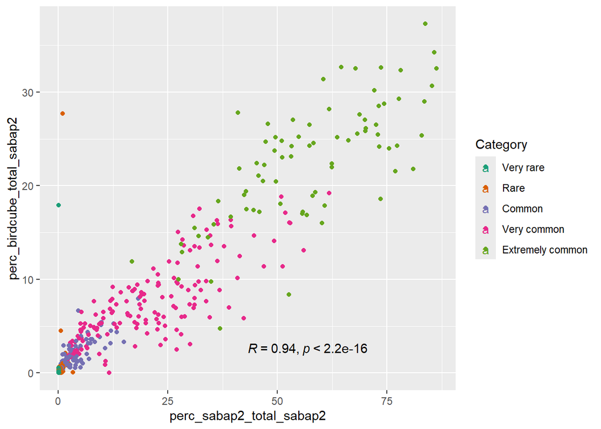

```r
# Plot percentage of SABAP2 grid cells in which species recorded in SABAP2 vs percentage overlapping cells in cube
comp_range_data %>%
  inner_join(SABAP2WCSub %>% distinct(species, category),
            by = join_by(studied_spec == species)) %>%
  ggplot(aes(x = perc_sabap2_total_sabap2, y = perc_birdcube_total_sabap2, color = category)) +
  geom_point() +
  colScale +
  ggpubr::stat_cor(mapping = aes(color = NULL),
           label.x.npc = "centre",
           label.y.npc = "bottom",
           method = "pearson")
```

If we look at the graph it appears that of the sabap2 grid cells the percentage of grid cells in which a species is observed in sabap2 is positively and strongly correlated to the percentage grid cells in which there is overlap between the sabap2 records and cube records.

### All species in SABAP2

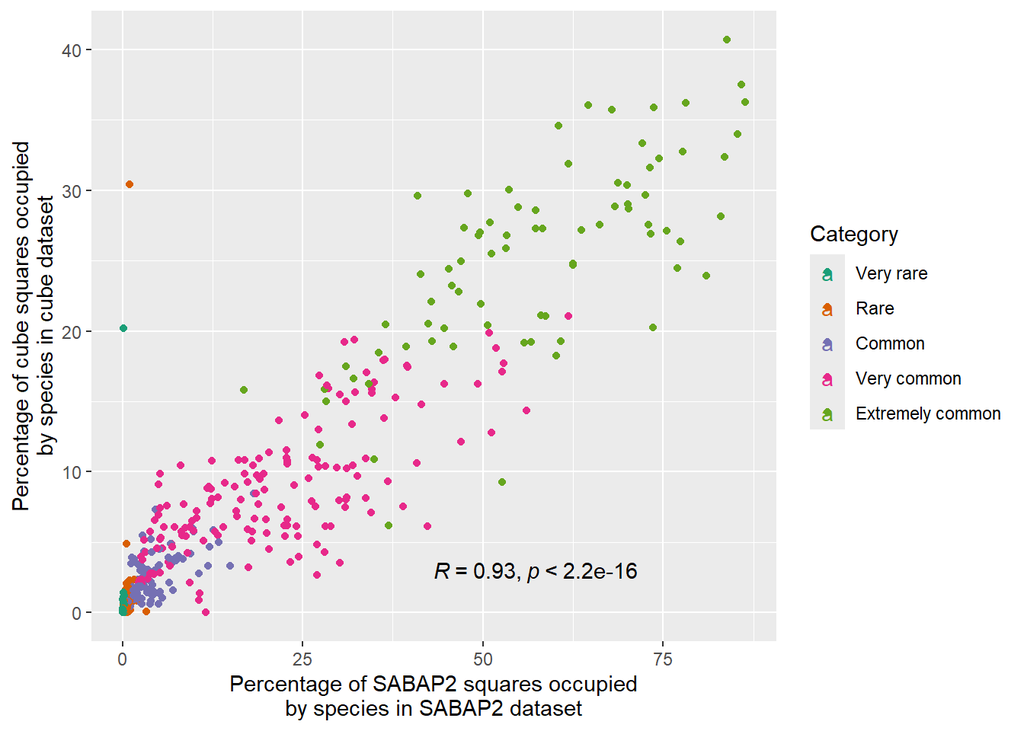

```r
# Plot percentage of SABAP2 grid cells in which species recorded in SABAP2 vs percentage of cells in which recorded in unstructured data
comp_range_data %>%
  inner_join(SABAP2WCSub %>% distinct(species, category),
            by = join_by(studied_spec == species)) %>%
  ggplot(aes(x = perc_sabap2_total_sabap2, y = perc_cube_total_cube, color = category)) +
  geom_point() +
  colScale +
  ggpubr::stat_cor(mapping = aes(color = NULL),
           label.x.npc = "centre",
           label.y.npc = "bottom",
           method = "pearson")+
  labs(x = "Percentage of SABAP2 squares occupied\nby species in SABAP2 dataset",
       y = "Percentage of cube squares occupied\nby species in cube dataset")
```

If we look at the graph it appears that of the sabap2 grid cells the percentage of grid cells in which a species is observed in sabap2 is strongly positively correlated to the percentage grid cells in which a species is recorded in the unstructured data. But note these grid cells might not overlap

### Only common, very common, and extremely common species in SABAP2

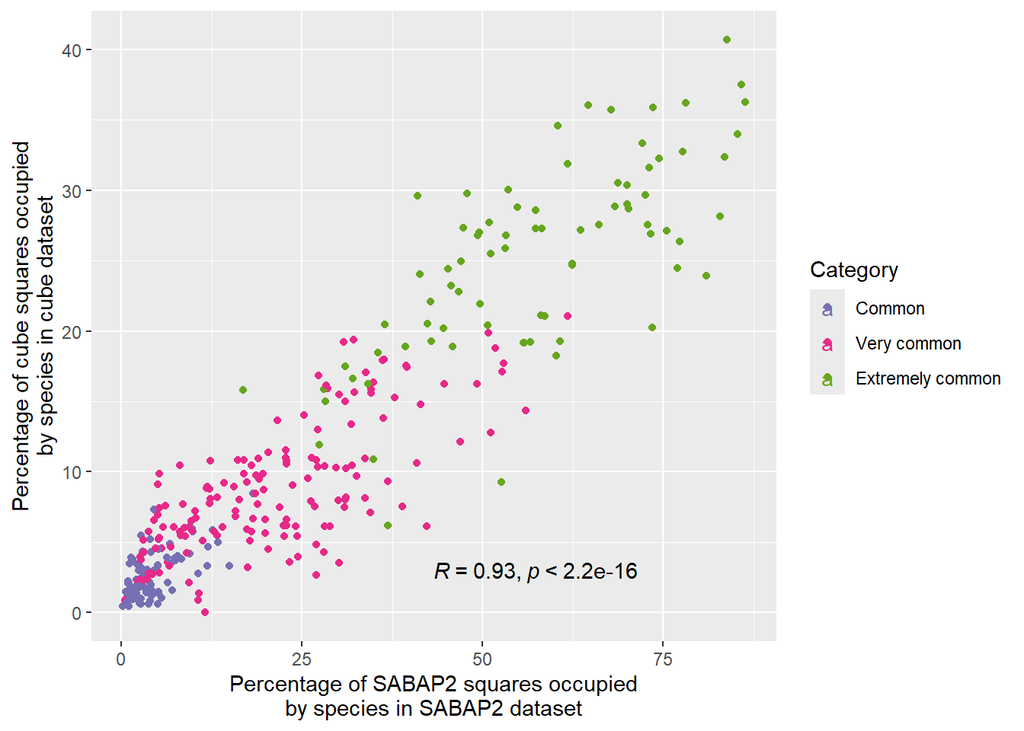

```r
# Plot percentage of SABAP2 grid cells in which species recorded in SABAP2 vs percentage of cells in which recorded in unstructured data (common, very common and extremely common species only)
comp_range_data %>%
  inner_join(SABAP2WCSub %>% distinct(species, category),
            by = join_by(studied_spec == species)) %>%
  filter(category %in% c("Common", "Very common", "Extremely common")) %>%
  ggplot(aes(x = perc_sabap2_total_sabap2, y = perc_cube_total_cube, color = category)) +
  geom_point() +
  colScale +
  ggpubr::stat_cor(mapping = aes(color = NULL),
           label.x.npc = "centre",
           label.y.npc = "bottom",
           method = "pearson")+
  labs(x = "Percentage of SABAP2 squares occupied\nby species in SABAP2 dataset",
       y = "Percentage of cube squares occupied\nby species in cube dataset")
```

For common, very common species, and extremely common species (very rare/rare excluded) - If we look at the graph it appears that of the sabap2 grid cells the percentage of grid cells in which a species is observed in sabap2 is positively correlated to the percentage grid cells in which a species is recorded in the unstructured data. But these grid cells might not overlap.

# Trend analysis

## Trend comparison with data aggregated per year

### All species in SAPAP2

```r
# No records per year per species
time_series_Y1 <- SABAP2WC %>%
  st_drop_geometry() %>%
  group_by(species, year) %>%
  summarize(occurrence = sum(occurrenceStatus == "PRESENT"))
# No records per year per species
time_series_Y2 <- UnstrucWC %>%
  st_drop_geometry()  %>%
  group_by(species, year)  %>%
  summarize(occurrence = sum(n))
# Pearson Correlation for each species
# inner_join makes sure that only species-year combinations present
# in both datasets are included
time_series_Y_cor <- time_series_Y1 %>%
  inner_join(time_series_Y2,
             by = c("species", "year"),
             suffix = c("_1", "_2")) %>%
  group_by(species) %>%
  summarize(correlation = cor(occurrence_1, occurrence_2, method = "pearson"))
# summarise correlations per commonness group
time_series_Y_cor<-time_series_Y_cor %>%
  inner_join(SABAP2WC %>% distinct(species, category),
             by = join_by(species == species))

time_series_Y_cor %>%
  group_by(category) %>%
  summarize(mean(correlation, na.rm = TRUE))
```

```
## # A tibble: 5 × 2
##   category         `mean(correlation, na.rm = TRUE)`
##   <fct>                                        <dbl>
## 1 Very rare                                   0.373
## 2 Rare                                        0.271
## 3 Common                                      0.0138
## 4 Very common                                -0.303
## 5 Extremely common                           -0.541
```

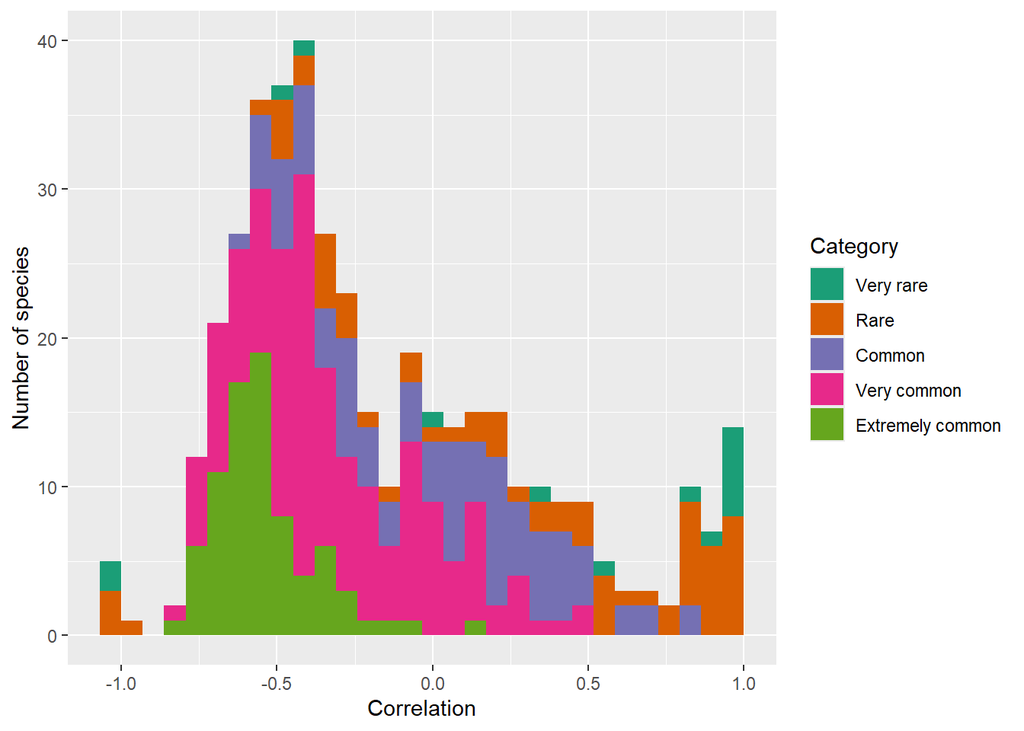

```r
# Visualise results
time_series_Y_cor %>%
  ggplot(aes(x = correlation, fill = category)) +
  geom_histogram() +
  fillScale +
  labs(x = "Correlation",
       y = "Number of species")
```

The correlations are poor, for most species, particularly very and extremely common species are negative.

### Common and very common species in SABAP2

```r
# No records per year per species
time_series_Y1Com <- SABAP2WC %>%
  st_drop_geometry() %>%
  filter(category %in% c("Common", "Very common", "Extremely common")) %>%
  group_by(species, year) %>%
  summarize(occurrence = sum(occurrenceStatus == "PRESENT"))
# Pearson Correlation for each species
# inner_join makes sure that only species-year combinations present
# in both datasets are included
time_series_YCom_cor <- time_series_Y1Com %>%
  inner_join(time_series_Y2,
             by = c("species", "year"),
             suffix = c("_1", "_2")) %>%
  group_by(species) %>%
  summarize(correlation = cor(occurrence_1, occurrence_2, method = "pearson"))
```

```r
# summarise correlations per commonness group
time_series_YCom_cor<-time_series_YCom_cor %>%
  inner_join(SABAP2WC %>% distinct(species, category),
             by = join_by(species == species))

time_series_YCom_cor %>%
  group_by(category) %>%
  summarize(mean(correlation, na.rm = TRUE))
```

```
## # A tibble: 3 × 2
##   category         `mean(correlation, na.rm = TRUE)`
##   <fct>                                        <dbl>
## 1 Common                                      0.0138
## 2 Very common                                -0.303
## 3 Extremely common                           -0.541
```

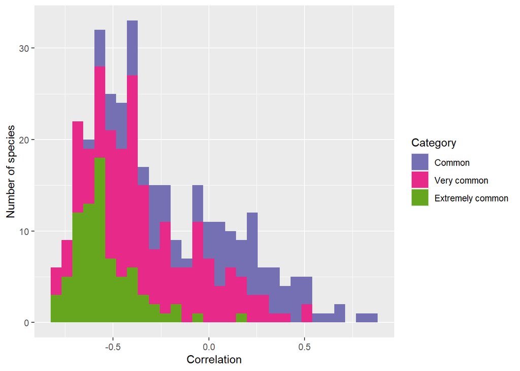

```r
# Visualise results
time_series_YCom_cor %>%
  ggplot(aes(x = correlation, fill = category)) +
  geom_histogram() +
  fillScale +
  labs(x = "Correlation",
       y = "Number of species")
```

Poor, mostly negative correletions.

### All species in SABAP2, but number of observations is weighed by total number of observations for that year

```r
# No records per year
total_year_1<-SABAP2WC %>%
  st_drop_geometry() %>%
  group_by(year) %>%
  summarize(Totalocc = sum(occurrenceStatus == "PRESENT"))

time_series_Y1adj <- SABAP2WC %>%
  st_drop_geometry() %>%
  group_by(species, year) %>%
  summarize(occurrence = sum(occurrenceStatus == "PRESENT")) %>% left_join(total_year_1) %>% mutate(occCorrect = occurrence/Totalocc)
# No records per year
total_year_2<-UnstrucWC %>%
  st_drop_geometry() %>%
  group_by(year) %>%
  summarize(Totalocc = sum(n))

# No records per year per species
time_series_Y2adj <- UnstrucWC %>%
  st_drop_geometry()  %>%
  group_by(species, year)  %>%
  summarize(occurrence = sum(n)) %>% left_join(total_year_2) %>% mutate(occCorrect = occurrence/Totalocc)
# Pearson Correlation for each species
# inner_join makes sure that only species-year combinations present
# in both datasets are included
time_series_Yadj_cor <- time_series_Y1adj %>%
  inner_join(time_series_Y2adj,
             by = c("species", "year"),
             suffix = c("_1", "_2")) %>%
  group_by(species) %>%
  summarize(correlation = cor(occCorrect_1, occCorrect_2, method = "pearson"))
```

```r
# summarise correlations per commonness group
time_series_Yadj_cor<-time_series_Yadj_cor %>%
  inner_join(SABAP2WC %>% distinct(species, category),
             by = join_by(species == species))

time_series_Yadj_cor %>%
  group_by(category) %>%
  summarize(mean(correlation, na.rm = TRUE))
```

```
## # A tibble: 5 × 2
##   category         `mean(correlation, na.rm = TRUE)`
##   <fct>                                        <dbl>
## 1 Very rare                                  0.348
## 2 Rare                                       0.168
## 3 Common                                     0.256
## 4 Very common                                0.108
## 5 Extremely common                           0.00700
```

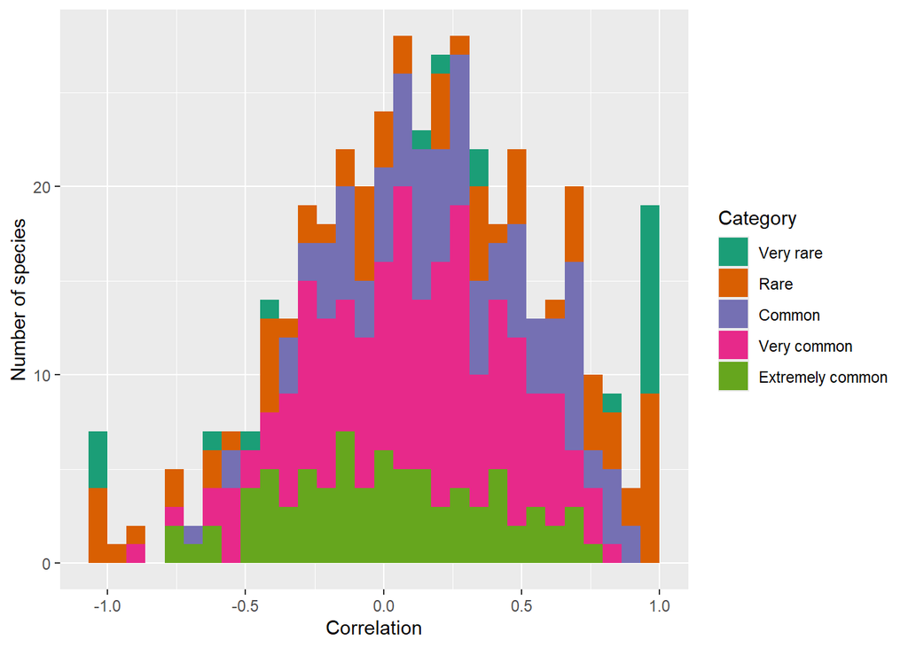

```r
# Visualise results
time_series_Yadj_cor %>%
  ggplot(aes(x = correlation, fill = category)) +
  geom_histogram() +
  fillScale +
  labs(x = "Correlation",
       y = "Number of species")
```

Graph shows for each species the degree to which the number of records over time in SABAP2 correlates with the number of records in the unstructured dataset. The strength and direction of the correlation varies between species, but is improved in comparison to when the data are not corrected for total number of records.

## Trend comparison with data aggregated per cyclus

### All species in SAPAP2

```r
# No records per time-period per species
time_series_Cyc1 <- SABAP2WC %>%
  st_drop_geometry() %>%
  group_by(species, cyclus) %>%
  summarize(occurrence = sum(occurrenceStatus == "PRESENT")) %>%
  filter(cyclus < 5)
# No records per time-period per species
time_series_Cyc2 <- UnstrucWC %>%
  st_drop_geometry()  %>%
  group_by(species, cyclus)  %>%
  summarize(occurrence = sum(n)) %>%
  filter(cyclus < 5)
# Pearson Correlation for each species
# inner_join makes sure that only species-time-period combinations present
# in both datasets are included
time_series_Cyc_cor <- time_series_Cyc1 %>%
  inner_join(time_series_Cyc2,
             by = c("species", "cyclus"),
             suffix = c("_1", "_2")) %>%
  group_by(species) %>%
  summarize(correlation = cor(occurrence_1, occurrence_2, method = "pearson"))
# summarise correlations per commonness group
time_series_Cyc_cor<-time_series_Cyc_cor %>%
  inner_join(SABAP2WC %>% distinct(species, category),
             by = join_by(species == species))

time_series_Cyc_cor %>%
  group_by(category) %>%
  summarize(mean(correlation, na.rm = TRUE))
```

```
## # A tibble: 5 × 2
##   category         `mean(correlation, na.rm = TRUE)`
##   <fct>                                        <dbl>
## 1 Very rare                                    0.322
## 2 Rare                                         0.393
## 3 Common                                       0.353
## 4 Very common                                  0.145
## 5 Extremely common                             0.285
```

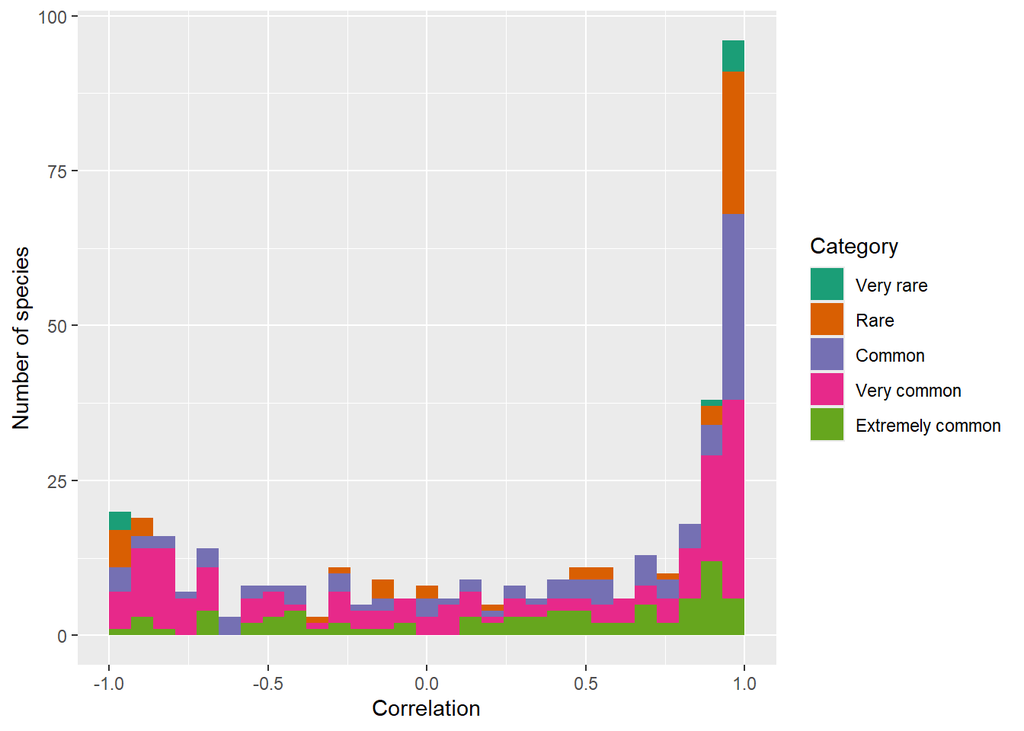

```r
# Visualise results
time_series_Cyc_cor %>%
  ggplot(aes(x = correlation, fill = category)) +
  geom_histogram() +
  fillScale +
  labs(x = "Correlation",
       y = "Number of species")
```

Graph shows for each species the degree to which the number of records over time in SABAP2 correlates with the number of records in the unstructured dataset. The strength and direction of the correlation varies between species, but is generally improved in comparision to when trends are compared for years.

### Common and very common species in SABAP2

```r
# No records per time-period per species
time_series_Cyc1Com <- SABAP2WC %>%
  st_drop_geometry() %>%
  filter(category %in% c("Common", "Very common", "Extremely common")) %>%
  group_by(species, cyclus) %>%
  summarize(occurrence = sum(occurrenceStatus == "PRESENT")) %>%
  filter(cyclus < 5)
# Pearson Correlation for each species
# inner_join makes sure that only species-time-period combinations present
# in both datasets are included
time_series_CycCom_cor <- time_series_Cyc1Com %>%
  inner_join(time_series_Cyc2,
             by = c("species", "cyclus"),
             suffix = c("_1", "_2")) %>%
  group_by(species) %>%
  summarize(correlation = cor(occurrence_1, occurrence_2, method = "pearson"))
```

```r
# summarise correlations per commonness group
time_series_CycCom_cor<-time_series_CycCom_cor %>%
  inner_join(SABAP2WC %>% distinct(species, category),
             by = join_by(species == species))

time_series_CycCom_cor %>%
  group_by(category) %>%
  summarize(mean(correlation, na.rm = TRUE))
```

```
## # A tibble: 3 × 2
##   category         `mean(correlation, na.rm = TRUE)`
##   <fct>                                        <dbl>
## 1 Common                                       0.353
## 2 Very common                                  0.145
## 3 Extremely common                             0.285
```

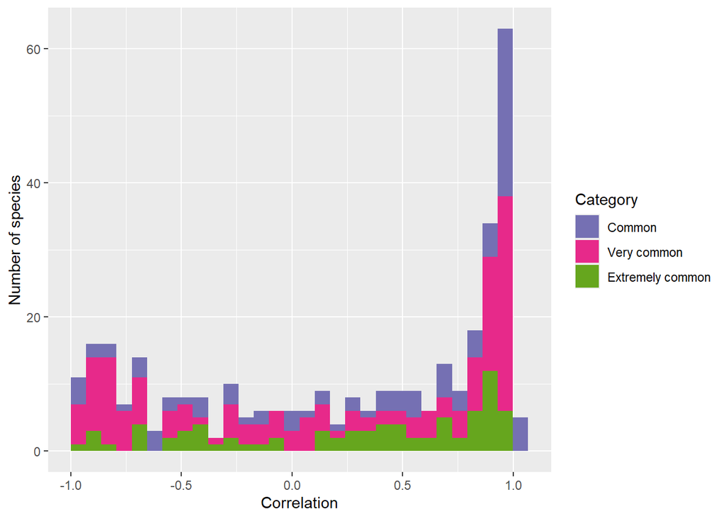

```r
# Visualise results
time_series_CycCom_cor %>%
  ggplot(aes(x = correlation, fill = category)) +
  geom_histogram() +
  fillScale +
  labs(x = "Correlation",
       y = "Number of species")
```

Correlations have improved in comparison to when trends are evaluated across years

### All species in SABAP2, but number of observations is weighed by total number of observations for that cyclus

```r
# No records per cyclus
total_cyc_1<-SABAP2WC %>%
  st_drop_geometry() %>%
  group_by(cyclus) %>%
  summarize(Totalocc = sum(occurrenceStatus == "PRESENT"))

time_series_Cyc1adj <- SABAP2WC %>%
  st_drop_geometry() %>%
  group_by(species, cyclus) %>%
  summarize(occurrence = sum(occurrenceStatus == "PRESENT")) %>%
  filter(cyclus < 5) %>%
  left_join(total_cyc_1) %>% mutate(occCorrect = occurrence/Totalocc)
# No records per cylus
total_cyc_2<-UnstrucWC %>%
  st_drop_geometry() %>%
  group_by(cyclus) %>%
  summarize(Totalocc = sum(n))

# No records per time-period per species
time_series_Cyc2adj <- UnstrucWC %>%
  st_drop_geometry()  %>%
  group_by(species, cyclus)  %>%
  summarize(occurrence = sum(n)) %>%
  filter(cyclus < 5) %>%
  left_join(total_cyc_2) %>% mutate(occCorrect = occurrence/Totalocc)
# Pearson Correlation for each species
# inner_join makes sure that only species-cyclus combinations present
# in both datasets are included
time_series_Cycadj_cor <- time_series_Cyc1adj %>%
  inner_join(time_series_Cyc2adj,
             by = c("species", "cyclus"),
             suffix = c("_1", "_2")) %>%
  group_by(species) %>%
  summarize(correlation = cor(occCorrect_1, occCorrect_2, method = "pearson"))
```

```r
# summarise correlations per commonness group
time_series_Cycadj_cor<-time_series_Cycadj_cor %>%
  inner_join(SABAP2WC %>% distinct(species, category),
             by = join_by(species == species))

time_series_Cycadj_cor %>%
  group_by(category) %>%
  summarize(mean(correlation, na.rm = TRUE))
```

```
## # A tibble: 5 × 2
##   category         `mean(correlation, na.rm = TRUE)`
##   <fct>                                        <dbl>
## 1 Very rare                                   0.398
## 2 Rare                                        0.286
## 3 Common                                      0.219
## 4 Very common                                -0.0445
## 5 Extremely common                           -0.0868
```

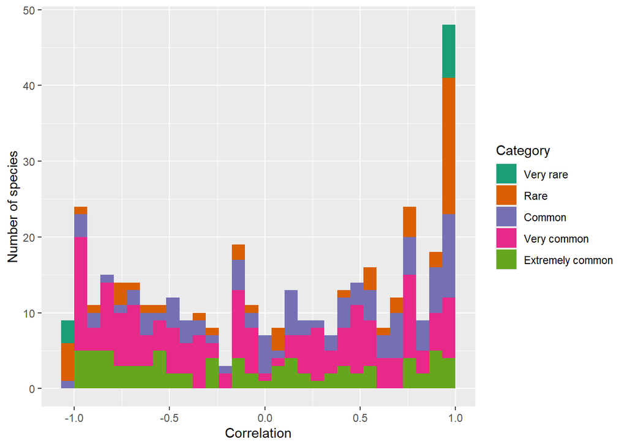

```r
# Visualise results
time_series_Cycadj_cor %>%
  ggplot(aes(x = correlation, fill = category)) +
  geom_histogram() +
  fillScale +
  labs(x = "Correlation",
       y = "Number of species")
```

Correcting for number of observations decreases correlations when data are binned into time periods.

```r
# table of results
time_series_Cycadj_cor %>%
  filter(category %in% c("Common", "Very common", "Extremely common"),
         correlation < 0.5) %>%
  DT::datatable() %>%
  DT::formatRound(columns = "correlation", digits = 2)
```

|  | species | correlation | category |
| --- | --- | --- | --- |
| 1 | Accipiter melanoleucus | -0.1661996875411555 | Very common |
| 2 | Accipiter rufiventris | -0.6462254329469034 | Common |
| 3 | Accipiter tachiro | -0.9689028216541 | Very common |
| 4 | Acrocephalus gracilirostris | -0.9152113000934654 | Extremely common |
| 5 | Alcedo semitorquata | 0.4061106405486043 | Common |
| 6 | Alopochen aegyptiaca | -0.5613079392970469 | Extremely common |
| 7 | Amadina erythrocephala | -0.01905811506557053 | Common |
| 8 | Anas capensis | -0.8151810484189166 | Very common |
| 9 | Anas platyrhynchos | -0.717501950449929 | Very common |
| 10 | Anas undulata | 0.1886140809377143 | Extremely common |

[output cut: 224 more lines]

## Trend similarity

```r
studied_spec <- unique(SABAP2WC$species) %>% na.omit()
```

```r
# Calculate number of SABAP2 records per species per time period, and change from one period to the next
sabap2_dif <- SABAP2WC %>%
  group_by(cyclus, species) %>%
  summarise(total = n()) %>% # no records in SABAP2 data
  pivot_wider(names_from = cyclus,
              names_prefix = "sabap2_",
              values_from = total,
              values_fill = 0) %>%
  mutate(dif1 = sabap2_2 - sabap2_1,
         dif2 = sabap2_3 - sabap2_2,
         dif3 = sabap2_4 - sabap2_3,
         dif4 = sabap2_5 - sabap2_4)
# Calculate number of unstructured records per species per time period, and change from one period to the next
cube_dif <- UnstrucWC %>%
  filter(species %in% studied_spec) %>%
  group_by(cyclus, species) %>%
  summarise(total = sum(n)) %>% # no records
  pivot_wider(names_from = cyclus,
              names_prefix = "cube_",
              values_from = total,
              values_fill = 0) %>%
  mutate(dif1_cube = cube_2 - cube_1,
         dif2_cube = cube_3 - cube_2,
         dif3_cube = cube_4 - cube_3,
        dif4_cube = cube_5 - cube_4) %>%
  select(species, dif1_cube, dif2_cube, dif3_cube, dif4_cube)
# Compare the changes over time periods per species between the two datasets
# TRUE if positive change, FALSE if negative change
comp_dir <- sabap2_dif %>%
  select(species, dif1, dif2, dif3, dif4) %>%
  inner_join(cube_dif) %>%
  mutate(dif1 = dif1 > 0,
         dif2 = dif2 > 0,
         dif3 = dif3 > 0,
         dif4 = dif4 > 0,
         dif1_cube = dif1_cube > 0,
         dif2_cube = dif2_cube > 0,
         dif3_cube = dif3_cube > 0,
         dif4_cube = dif4_cube > 0) %>%
  pivot_longer(
    cols = !species
  ) %>%
  mutate(set = ifelse(str_detect(name, "cube"),
                      "cube",
                      "sabap2")) %>%
  mutate(dif = str_sub(name, 1, 4)) %>%
  select(-name) %>%
  pivot_wider(names_from = set,
              values_from = value)
# Perform Kappa analysis (how well do the two datasets agree in terms of change direction)
vcd::Kappa(table(comp_dir[,c(3,4)]))
```

```
##             value     ASE     z  Pr(>|z|)
## Unweighted 0.2425 0.01978 12.26 1.545e-34
## Weighted   0.2425 0.01978 12.26 1.545e-34
```

K value = 0.2425, so there is a ‘fair’ agreement in trends in number of records over time

```r
# Calculate number of SABAP2 records per rare species per time period, and change from one period to the next
sabap2_dif <- SABAP2WC %>%
  filter(category %in% c("Rare")) %>%
  group_by(cyclus, species) %>%
  summarise(total = n()) %>% # no records
  pivot_wider(names_from = cyclus,
              names_prefix = "sabap2_",
              values_from = total,
              values_fill = 0) %>%
  mutate(dif1 = sabap2_2 - sabap2_1,
         dif2 = sabap2_3 - sabap2_2,
         dif3 = sabap2_4 - sabap2_3,
         dif4 = sabap2_5 - sabap2_4)
# Calculate number of unstructured data records per rare species per time period, and change from one period to the next
cube_dif <- UnstrucWC %>%
  filter(species %in% sabap2_dif$species) %>%
  group_by(cyclus, species) %>%
  summarise(total = sum(n)) %>%
  pivot_wider(names_from = cyclus,
              names_prefix = "cube_",
              values_from = total,
              values_fill = 0) %>%
  mutate(dif1_cube = cube_2 - cube_1,
         dif2_cube = cube_3 - cube_2,
         dif3_cube = cube_4 - cube_3,
         dif4_cube = cube_5 - cube_4) %>%
  select(species, dif1_cube, dif2_cube, dif3_cube, dif4_cube)
# Compare the changes over time periods per rare species between the two datasets
# TRUE if positive change, FALSE if negative change
comp_dir <- sabap2_dif %>%
  select(species, dif1, dif2, dif3, dif4) %>%
  inner_join(cube_dif) %>%
  mutate(dif1 = dif1 > 0,
         dif2 = dif2 > 0,
         dif3 = dif3 > 0,
         dif4 = dif4 > 0,
         dif1_cube = dif1_cube > 0,
         dif2_cube = dif2_cube > 0,
         dif3_cube = dif3_cube > 0,
         dif4_cube = dif4_cube > 0) %>%
  pivot_longer(
    cols = !species
  ) %>%
  mutate(set = ifelse(str_detect(name, "cube"),
                      "cube",
                      "sabap2")) %>%
  mutate(dif = str_sub(name, 1, 4)) %>%
  select(-name) %>%
  pivot_wider(names_from = set,
              values_from = value)
# Perform Kappa analysis (how well do the two datasets agree in terms of change direction)
vcd::Kappa(table(comp_dir[,c(3,4)]))
```

```
##             value     ASE    z  Pr(>|z|)
## Unweighted 0.4125 0.05086 8.11 5.044e-16
## Weighted   0.4125 0.05086 8.11 5.044e-16
```

Kappa value = 0.4125, and so there is a ‘moderate’ agreement in trends in number of records over time

# Occupancy rate comparrison

```r
# Give '1' to the grid cells each species is recorded in SABAP2
occupancy_1 <- SABAP2WC %>%
  group_by(species, pentad) %>%
  summarize(occupancy_rate_1 = mean(occurrenceStatus == "PRESENT"))
# Give '1' to the grid cells each species is recorded in unstructured data
occupancy_2 <- UnstrucWC %>%
  group_by(species, pentad) %>%
  summarize(occupancy_rate_2 = 1)
# Calculate per species, the number of cells occupied in SABAP2, number of cells occupied in unstructured data, and percentage of cells occupied in SABAP2 data that are occupied in unstructured data
occupancy<-occupancy_1 %>% left_join(occupancy_2,
            by = join_by(species, pentad)) %>%
  replace_na(list(occupancy_rate_2 = 0)) %>%
  group_by(species)%>%
  summarise(SabapOcc = sum(occupancy_rate_1), UnstrucOcc = sum(occupancy_rate_2), PercOcc = (UnstrucOcc/SabapOcc)*100)

mean(occupancy$PercOcc) # average % occupancy overlap
```

```
## [1] 43.38169
```

Low average occupancy across species (43%). 43% of cells occupied in SABAP2 data are on average occupied in unstructured data

# Species richness and composition

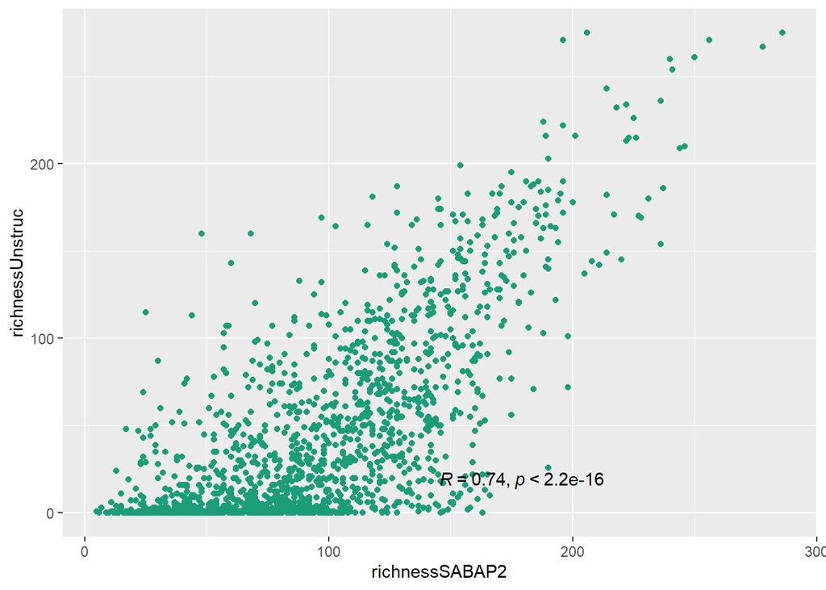

```r
# Species richness per pentad
richness_1 <- SABAP2WC %>%
  group_by(pentad) %>%
  summarize(richnessSABAP2 = n_distinct(species))

richness_2 <- UnstrucWC %>%
  filter(species %in% studied_spec) %>%
  group_by(pentad) %>%
  summarize(richnessUnstruc = n_distinct(species))

# Plot correlation
richness_1 %>% left_join(richness_2,
            by = join_by(pentad)) %>%
  replace_na(list(richnessUnstruc = 0)) %>%
    ggplot(aes(x = richnessSABAP2, y = richnessUnstruc)) +
  geom_point(color = "#1B9E77") +
  ggpubr::stat_cor(mapping = aes(color = NULL),
           label.x.npc = "centre",
           label.y.npc = "bottom",
           method = "pearson")
```

Positive and significant correlation between species richness calculated from the two datasets. Is a lot of scatter though

```r
# Bray-Curtis dissimilarity
# Number of records per species in sabap2
species_composition_1 <- SABAP2WC %>%
  drop_na(species) %>%
  count(species) %>% # number of records per species
  pivot_wider(names_from = species,
              values_from = n,
              values_fill = 0)

# Number of records per species in unstuctured data
species_composition_2 <- UnstrucWC %>%
  filter(species %in% studied_spec) %>%
  group_by(species) %>%
  summarise(n = sum(n)) %>% # number of records per species***
  pivot_wider(names_from = species,
              values_from = n,
              values_fill = 0)

# make sure the two datasets have the same columns
addSpp<-setdiff(colnames(species_composition_1), colnames(species_composition_2))
species_composition_2<- species_composition_2 %>% bind_cols(setNames(rep(list(0), length(addSpp)), addSpp))
species_composition_2<-species_composition_2[colnames(species_composition_1)]

#Bray curtis
bray_curtis <- vegan::vegdist(rbind(species_composition_1[-1],
                             species_composition_2[-1]), method = "bray")
bray_curtis
```

```
##           1
## 2 0.2238699
```

Bray curtis index of 0.22 indicates similar species composition